# Project 3

Siyu Zou

2023-10-13

```r
# b_lyrics <- readr::read_csv("https://raw.githubusercontent.com/rfordatascience/tidytuesday/master/data/2020/2020-09-29/beyonce_lyrics.csv")
# ts_lyrics <- readr::read_csv("https://raw.githubusercontent.com/rfordatascience/tidytuesday/master/data/2020/2020-09-29/taylor_swift_lyrics.csv")
# sales <- readr::read_csv("https://raw.githubusercontent.com/rfordatascience/tidytuesday/master/data/2020/2020-09-29/sales.csv")

# library("here")
rds_files <- c("b_lyrics.RDS", "ts_lyrics.RDS", "sales.RDS")
## Check whether we have all 3 files
if (any(!file.exists(here("data", rds_files)))) {
    ## If we don't, then download the data
    b_lyrics <- readr::read_csv("https://raw.githubusercontent.com/rfordatascience/tidytuesday/master/data/2020/2020-09-29/beyonce_lyrics.csv")
    ts_lyrics <- readr::read_csv("https://raw.githubusercontent.com/rfordatascience/tidytuesday/master/data/2020/2020-09-29/taylor_swift_lyrics.csv")
    sales <- readr::read_csv("https://raw.githubusercontent.com/rfordatascience/tidytuesday/master/data/2020/2020-09-29/sales.csv")

    ## Then save the data objects to RDS files
    saveRDS(b_lyrics, file = here("data", "b_lyrics.RDS"))
    saveRDS(ts_lyrics, file = here("data", "ts_lyrics.RDS"))
    saveRDS(sales, file = here("data", "sales.RDS"))
}

b_lyrics <- readRDS(here("data", "b_lyrics.RDS"))
ts_lyrics <- readRDS(here("data", "ts_lyrics.RDS"))
sales <- readRDS(here("data", "sales.RDS"))
```

# Part 1: Explore album sales

In this section, the goal is to explore the sales of studio albums from Beyoncé and Taylor Swift.

## Part 1A

```r
# library("lubridate")
# library("forcats")
# library(tidyverse)

pattern <- "\\s*\\([^)]+\\)\\[\\d+\\]"
sales$released <-  stringr::str_replace_all(sales$released, pattern, "")

sales$released <- mdy(sales$released)

table(sales$country)
```

```
##
##   AUS   CAN    FR   FRA   JPN    UK    US World    WW
##     1     3     1     3     3    12    13     5     6
```

```r
summary(sales$sales)
```

```
##     Min.  1st Qu.   Median     Mean  3rd Qu.     Max.     NA's
##     5700   353000  1500000  2873009  4847000 12000000        1
```

```r
sales_new <- sales %>%
  mutate(country = fct_collapse(country,
                                "UK" = c("UK"),
                                "US" = c("US"),
                                "the World" = c("World", "WW"),
                                "other" = c("AUS", "CAN", "FR","FRA","JPN")           )) %>%
  mutate(sales_million = sales/1000000) %>%
  filter(
    country %in% c("UK" , "US" , "the World")
  ) %>%
  print
```

```
## # A tibble: 36 × 9
##    artist       title    country  sales released   re_re…¹ label formats sales…²
##    <chr>        <chr>    <fct>    <dbl> <date>     <chr>   <chr> <chr>     <dbl>
##  1 Taylor Swift Taylor … US      5.72e6 2006-10-24 March … Big … CD, CD…   5.72
##  2 Taylor Swift Fearless the Wo… 1.2 e7 2008-11-11 Octobe… Big … CD, CD…  12
##  3 Taylor Swift Fearless US      7.18e6 2008-11-11 Octobe… Big … CD, CD…   7.18
##  4 Taylor Swift Fearless UK      6.09e5 2008-11-11 Octobe… Big … CD, CD…   0.609
##  5 Taylor Swift Speak N… the Wo… 5   e6 2010-10-25 <NA>    Big … CD, CD…   5
##  6 Taylor Swift Speak N… US      4.69e6 2010-10-25 <NA>    Big … CD, CD…   4.69
##  7 Taylor Swift Speak N… UK      1.69e5 2010-10-25 <NA>    Big … CD, CD…   0.169
##  8 Taylor Swift Red      the Wo… 6   e6 2012-10-22 <NA>    Big … CD, CD…   6
##  9 Taylor Swift Red      US      4.46e6 2012-10-22 <NA>    Big … CD, CD…   4.46
## 10 Taylor Swift Red      UK      6.93e5 2012-10-22 <NA>    Big … CD, CD…   0.693
## # … with 26 more rows, and abbreviated variable names ¹re_release,
## #   ²sales_million
```

## Part 1B

In this section, we will do some more data wrangling followed by summarization using wrangled data from Part 1A.

Keep only album sales from the US. Create a new column called years_since_release corresponding to the number of years since the release of each album from Beyoncé and Taylor Swift. This should be a whole number and you should round down to “14” if you get a non-whole number like “14.12” years. (Hint: you may find the interval() function from lubridate helpful here, but this not the only way to do this.) Calculate the most recent, oldest, and the median years since albums were released for both Beyoncé and Taylor Swift.

```r
sales_new2 <- sales_new %>%
  filter( country == "US" ) %>%
  mutate(
    years_since_release = as.numeric(interval(start = released, end = today() ) / dyears(1)  ) ,
    years_since_release = round(years_since_release)
    )

US_sales_summary <- sales_new2 %>%
  group_by(artist) %>%
  summarise(
    most_recent <- min(years_since_release),
    oldest <- max(years_since_release),
    median_years <- median(years_since_release)
  ) %>%
  print
```

```
## # A tibble: 2 × 4
##   artist       `most_recent <- min(years_since_release)` oldest <- max…¹ media…²
##   <chr>                                            <dbl>           <dbl>   <dbl>
## 1 Beyoncé                                              7              20    13.5
## 2 Taylor Swift                                         4              17    11
## # … with abbreviated variable names ¹`oldest <- max(years_since_release)`,
## #   ²`median_years <- median(years_since_release)`
```

## Part 1C

Using the wrangled data from Part 1A:

Calculate the total album sales for each artist and for each country (only sales from the UK, US, and World). Using the total album sales, create a percent stacked barchart using ggplot2 of the percentage of sales of studio albums (in millions) along the y-axis for the two artists along the x-axis colored by the country.

```r
total_album_sales <- sales_new %>%
  group_by(artist, country) %>%
  summarise(
    total_sales = sum(sales_million)
  ) %>%
  ungroup() %>%
  group_by(artist) %>%
  mutate( percentage = total_sales/sum(total_sales)   )
```

[figure not shown]

```r
total_album_sales %>%
  ggplot(aes( artist, percentage, fill = country)) +
  geom_bar(position = "fill", stat = "identity") +
  scale_y_continuous(labels = scales::percent_format(scale = 1)) +
  labs(
    title = "Percentage of sales of studio albums",
    x = "Artists",
    y = "Sales of studio albums (in millions)",
    fill = "Country"
  ) +
  theme(
    plot.title = element_text(hjust = 0.5, color = "black", face = "bold", size = 15)
  )
```

## Part 1D

Using the wrangled data from Part 1A, use ggplot2 to create a bar plot for the sales of studio albums (in millions) along the x-axis for each of the album titles along the y-axis.

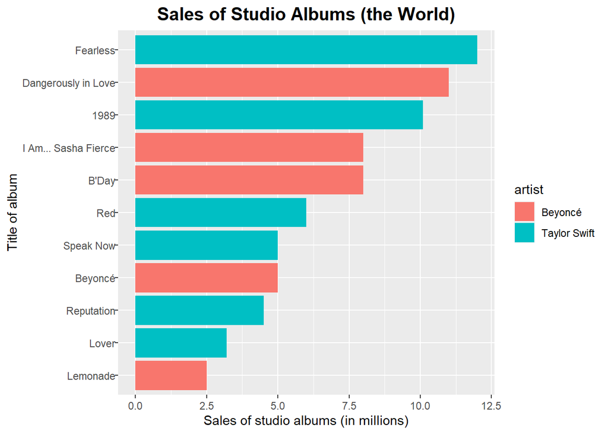

```r
sales_new %>%
  filter(country == "the World") %>%
  ggplot(aes(sales_million, y = fct_reorder(.f = title, .x = sales_million), fill = artist)) +
  geom_bar(stat = "identity" ) +
  labs(
    title = "Sales of Studio Albums (the World)",
    x = "Sales of studio albums (in millions)",
    y = "Title of album"
  ) +
  theme(
    plot.title = element_text(hjust = 0.5,color = "black", face = "bold", size = 15 ),
    axis.text.y = element_text(hjust = 1,  margin = margin(r = -0.5))
    )
```

## Part 1E

Using the wrangled data from Part 1A, use ggplot2 to create a scatter plot of sales of studio albums (in millions) along the y-axis by the released date for each album along the x-axis.

Note:

The points should be colored by the artist. There should be three scatter plots (one for UK, US and world sales) faceted by rows.

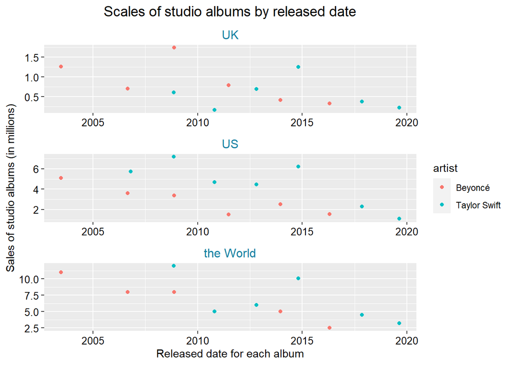

```r
sales_new %>%
  ggplot(aes(released, sales_million)) +
  geom_point( aes(color = artist )) +
  facet_wrap(~country, nrow = 3, scales = "free") +
  labs(
    title = "Scales of studio albums by released date",
    x = "Released date for each album",
    y = "Sales of studio albums (in millions)"
  ) +
  theme(
    plot.title = element_text(hjust = 0.5, size = 14),
    strip.text = element_text(color = "#1380A1" , size = 12),
    strip.background = element_rect(fill = "white", color = "white", linewidth = 1  ),
    axis.text = element_text(  color = "black", size = 10)
  )
```

# Part 2: Exploring sentiment of lyrics

In Part 2, we will explore the lyrics in the b_lyrics and ts_lyrics datasets.

## Part 2A

### hello lines

```r
# library(tidyverse)
# library(tidytext) ## needs to be installed

ts_lyrics_new <- unnest_lines( ts_lyrics, output = line ,input = Lyrics )

ts_lyrics_new <- ts_lyrics_new %>%
  mutate (number =  str_count(line, pattern = "hello"))

total_hello <- ts_lyrics_new %>%
  filter(number == 1)

total_hello
```

```
## # A tibble: 6 × 5
##   Artist       Album    Title                  line                       number
##   <chr>        <chr>    <chr>                  <chr>                       <int>
## 1 Taylor Swift Fearless Love Story             "and say, \"hello\""            1
## 2 Taylor Swift Red      I Almost Do            "that i can't say \"hello…      1
## 3 Taylor Swift Red      Everything Has Changed "'cause all i know is we …      1
## 4 Taylor Swift Red      Everything Has Changed "'cause all i know is we …      1
## 5 Taylor Swift Red      Everything Has Changed "all i know is we said he…      1
## 6 Taylor Swift Red      Everything Has Changed "all i know is we said he…      1
```

```r
nrow(total_hello)
```

```
## [1] 6
```

```r
ts_lyrics_new <- ts_lyrics_new %>%
  mutate (number =  str_count(line, pattern = "goodbye"))

total_goodbye <- ts_lyrics_new %>%
  filter(number == 1)
total_goodbye
```

```
## # A tibble: 12 × 5
##    Artist       Album        Title                      line              number
##    <chr>        <chr>        <chr>                      <chr>              <int>
##  1 Taylor Swift Taylor Swift Tied Together With A Smile "goodbye, baby"        1
##  2 Taylor Swift Speak Now    Mine                       "braced myself f…      1
##  3 Taylor Swift Speak Now    Back to December           "you gave me all…      1
##  4 Taylor Swift Speak Now    Long Live                  "and force us in…      1
##  5 Taylor Swift Red          I Almost Do                "and risk anothe…      1
##  6 Taylor Swift Red          Come Back Be Here          "stumbled throug…      1
##  7 Taylor Swift 1989         All You Had to Do Was Stay "but people like…      1
##  8 Taylor Swift reputation   Getaway Car                "said goodbye in…      1
##  9 Taylor Swift reputation   Getaway Car                "said goodbye in…      1
## 10 Taylor Swift Lover        Death By A Thousand Cuts   "saying goodbye …      1
## 11 Taylor Swift Lover        Death By A Thousand Cuts   "'cause saying g…      1
## 12 Taylor Swift Lover        Daylight                   "i'll tell you t…      1
```

```r
nrow(total_goodbye)
```

```
## [1] 12
```

12 lines in Taylor Swift’s lyrics contain the word “goodbye”

## Part 2B

```r
# b_lyrics_new <- unnest_lines( b_lyrics, output = line ,input = line )
# b_lyrics_new <- b_lyrics_new %>%
#   mutate (number =  str_count(line, pattern = "hello"))

b_lyrics_new <- b_lyrics %>%
  unnest_tokens(output = line, input = line, token = "lines")

total_hello <- b_lyrics_new %>%
  filter(str_detect(line, "hello"))

nrow(total_hello)
```

```
## [1] 91
```

91 lines in Beyonce’s lyrics contain the word “hello”

```r
# b_lyrics_new <- b_lyrics_new %>%
#   mutate (number =  str_count(line, pattern = "goodbye"))
total_goodbye <- b_lyrics_new %>%
  filter(str_detect(line, "goodbye"))

nrow(total_goodbye)
```

```
## [1] 12
```

12 lines in Beyonce’s lyrics contain the word “goodbye”

## Part 2C

Using the b_lyrics dataset,

Tokenize each lyrical line by words. Remove the “stopwords”. Calculate the total number for each word in the lyrics. Using the “bing” sentiment lexicon, add a column to the summarized data frame adding the “bing” sentiment lexicon. Sort the rows from most frequent to least frequent words. Only keep the top 25 most frequent words. Auto print the wrangled tibble data frame. Use ggplot2 to create a bar plot with the top words on the y-axis and the frequency of each word on the x-axis. Color each bar by the sentiment of each word from the “bing” sentiment lexicon. Bars should be ordered from most frequent on the top to least frequent on the bottom of the plot. Create a word cloud of the top 25 most frequent words.

```r
b_lyrics_words <- b_lyrics_new %>%
  unnest_tokens(word, line, token = "words" ) %>%
  anti_join(stop_words)
b_lyrics_words_sentiments <- b_lyrics_words  %>%
  count(word, sort = TRUE)  %>%
  inner_join( get_sentiments("bing") )
b_lyrics_top <- b_lyrics_words_sentiments[1:25, ]
b_lyrics_top
```

```
## # A tibble: 25 × 3
##    word          n sentiment
##    <chr>     <int> <chr>
##  1 love       1362 positive
##  2 crazy       308 negative
##  3 top         241 positive
##  4 bad         132 negative
##  5 beautiful   131 positive
##  6 whoa        121 positive
##  7 damn        106 negative
##  8 hurt         90 negative
##  9 hard         87 negative
## 10 ready        85 positive
## # … with 15 more rows
```

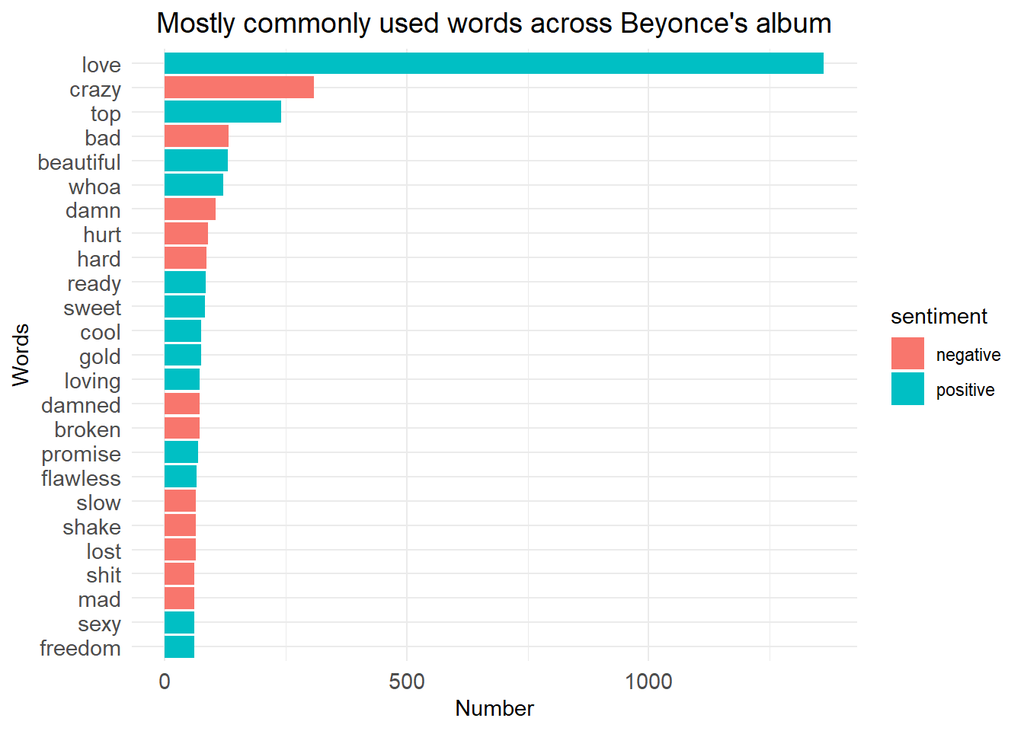

```r
b_lyrics_top %>%
  mutate(word = fct_reorder(word, n)) %>%
  ggplot(aes(n , word , fill = sentiment)) +
  geom_bar( stat = "identity"  ) +
  labs(
    title = "Mostly commonly used words across Beyonce's album",
    x = "Number",
    y = "Words"
  ) +
  theme_minimal() +
  theme(
    plot.title = element_text(hjust = 0.5, size = 14 ),
    axis.text = element_text(size = 11)
  )
```

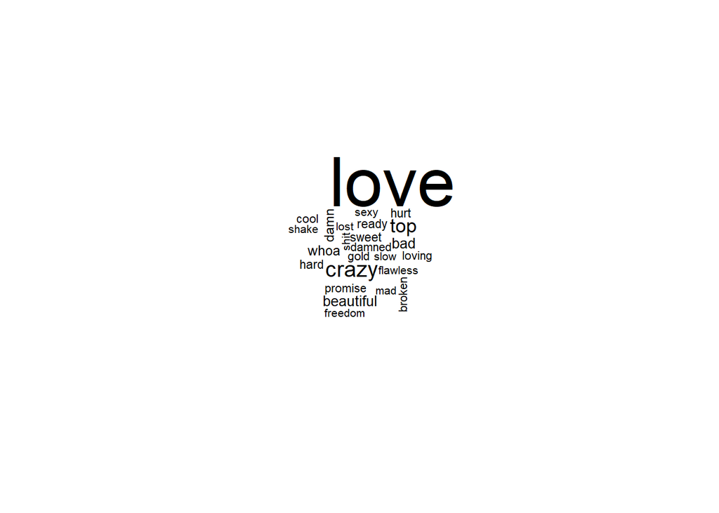

```r
# library(wordcloud)
b_lyrics_top %>%
  with(wordcloud(word, n) )
```

## Part 2D

for ts_lyrics

```r
ts_lyrics_words <- ts_lyrics_new %>%
  unnest_tokens(word, line, token = "words" ) %>%
  anti_join(stop_words)
ts_lyrics_words_sentiments <- ts_lyrics_words  %>%
  count(word, sort = TRUE)  %>%
  inner_join( get_sentiments("bing") )
ts_lyrics_top <- ts_lyrics_words_sentiments[1:25, ]
ts_lyrics_top
```

```
## # A tibble: 25 × 3
##    word          n sentiment
##    <chr>     <int> <chr>
##  1 love        248 positive
##  2 bad          80 negative
##  3 shake        73 negative
##  4 break        59 negative
##  5 mad          48 negative
##  6 beautiful    46 positive
##  7 smile        45 positive
##  8 hate         44 negative
##  9 fall         43 negative
## 10 whoa         36 positive
## # … with 15 more rows
```

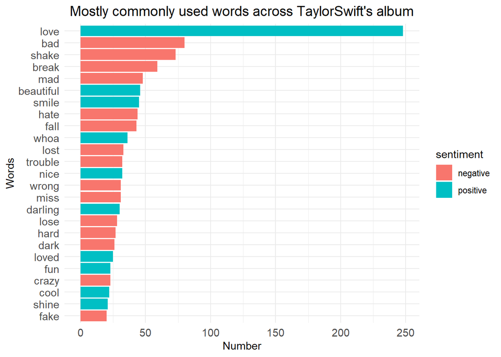

```r
ts_lyrics_top %>%
  mutate(word = fct_reorder(word, n)) %>%
  ggplot(aes(n , word , fill = sentiment)) +
  geom_bar( stat = "identity"  ) +
  labs(
    title = "Mostly commonly used words across TaylorSwift's album",
    x = "Number",
    y = "Words"
  ) +
  theme_minimal() +
  theme(
    plot.title = element_text(hjust = 0.5, size = 14 ),
    axis.text = element_text(size = 11)
  )
```

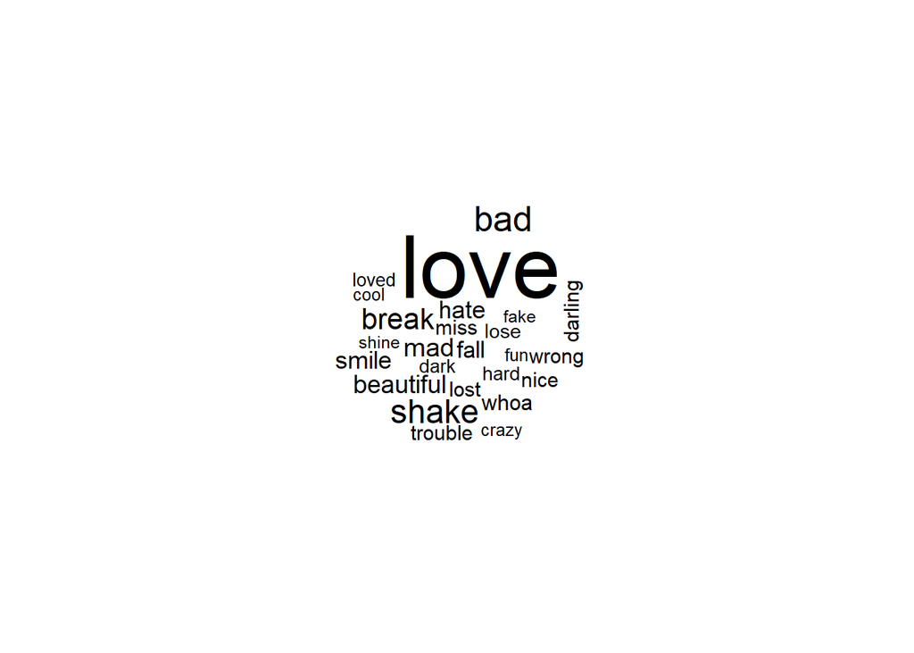

```r
ts_lyrics_top %>%
  with(wordcloud(word, n) )
```

## Part 2E

```r
ts_lyrics_E <- ts_lyrics %>%
  unnest_tokens(word, Lyrics, token = "words" ) %>%
  anti_join(stop_words)
ts_lyrics_count <- ts_lyrics_E %>%
  group_by(Album) %>%
  count(word, sort = TRUE)


average_score <-  ts_lyrics_E %>%
  inner_join(get_sentiments("afinn"))  %>%
  group_by(Album) %>%
  summarise(
     mean_sentiment_score = mean(value)
   )
average_score
```

```
## # A tibble: 8 × 2
##   Album        mean_sentiment_score
##   <chr>                       <dbl>
## 1 1989                      -0.215
## 2 Fearless                   0.452
## 3 folklore                  -0.396
## 4 Lover                      0.0960
## 5 Red                        0.256
## 6 reputation                 0.0501
## 7 Speak Now                  0.0219
## 8 Taylor Swift               0.646
```

[figure not shown]

```r
sales_new %>%
  rename( Album = title) %>%
  right_join(average_score, by = "Album" ) %>%
  ggplot(aes(x = released, y = mean_sentiment_score, size = sales)) +
  geom_point( ) +
  geom_hline(yintercept = 0) +
  labs(
    title = "Average sentiment score for each album",
    subtitle = "The sentiment of Taylor's albums have changed to negative over time",
    x = "Album release data",
    y = "Average sentiment score",
    size = "Sales(in millions)"
  ) +
  theme_minimal() +
  theme(
    plot.title = element_text(hjust = 0.5, size = 14 ),
    plot.subtitle = element_text(hjust = 0.5, size = 12),
    axis.text = element_text(size = 11)
  )
```